# Predicting Fall

Anastasia Bernat

1/25/2021

Using delta_yes_no.Rmd models to predict Fall delta flight response.

**Clean the data**

```r
source("src/clean_flight_data-Fall.R")
data = clean_flight_data.Fall("data/all_flight_data-Fall2019.csv")
```

**Keeping only the tests that were similar to Winter experiment design**

```r
data_mass = data %>%
  filter(!is.na(mass))

# 60 min trial
data60 = data_mass %>%
  filter(set_number < 53)

# 90 min trial
data90 = data_mass %>%
  filter(set_number < 72 & set_number > 52)

# ongoing trial
ongoing_data = data_mass %>%
  filter(set_number > 71)
```

**Create delta data**

```r
source("src/unique_flight_data-Fall.R")
d = create_delta_data.Fall(ongoing_data)
```

**Calculating individual predicted probabilities**

This is the format:

$\pi_j = \frac{e^{\alpha_j + \beta_j x}}{\sum_he^{\alpha_h + \beta_h x}}, j=1,...,J$

Here are the equations:

- [1] “Where F = 1”
- [1] “log(pi_-1 / pi_1) = 5.81 + 0.05 Mass Percent Change + 4.93 Sex Flew in T1, rather than T2”
- [2] “log(pi_2 / pi_-1) = 1.14 + -0.02 Mass Percent Change + -0.21 Sex Flew in both, rather than T1”
- [3] “log(pi_2 / pi_1) = 6.94 + 0.03 Mass Percent Change + 4.72 Sex Flew in both, rather than T2”
- [4] “log(pi_-1 / pi_0) = -1.02 + 0.043 Mass Percent Change - 0.69 Sex Flew in T1, rather than none”
- [5] “log(pi_1 / pi_0) = -6.82 - 0.009 Mass Percent Change - 5.63 Sex Flew in both, rather than none”
- [6] “log(pi_2 / pi_0) = 0.12 + 0.019 Mass Percent Change - 0.90 Sex Flew in both, rather than none”

**Codifying individual predicted probability equations**

```r
d <- d[with(d, order(mass_per)),]
```

```r
neither = c()
T1_rather_than_none = c()
T2_rather_than_none = c()
both_rather_than_none = c()
for (i in 1:nrow(d)) {
  mp = d$mass_per[[i]]
  s = d$sex_c[[i]]
  top0 = exp(0) # just equals 1
  top1 = exp(-1.02 + 0.043*mp - 0.69*s)
  top2 = exp(-6.82 - 0.009*mp - 5.63*s)
  top3 = exp(0.12 + 0.019*mp- 0.90*s)
  bottom = top0 + top1 + top2 + top3
  neither = c(neither, top0/bottom)
  T1_rather_than_none = c(T1_rather_than_none, top1/bottom)
  T2_rather_than_none = c(T2_rather_than_none, top2/bottom)
  both_rather_than_none = c(both_rather_than_none, top3/bottom)
}
```

**Plotting predicted probabilities**

```r
d$index = 1:nrow(d)
females = d %>%
  filter(sex=="F")
males = d %>%
  filter(sex=="M")
Frows = females$index
Mrows = males$index
```

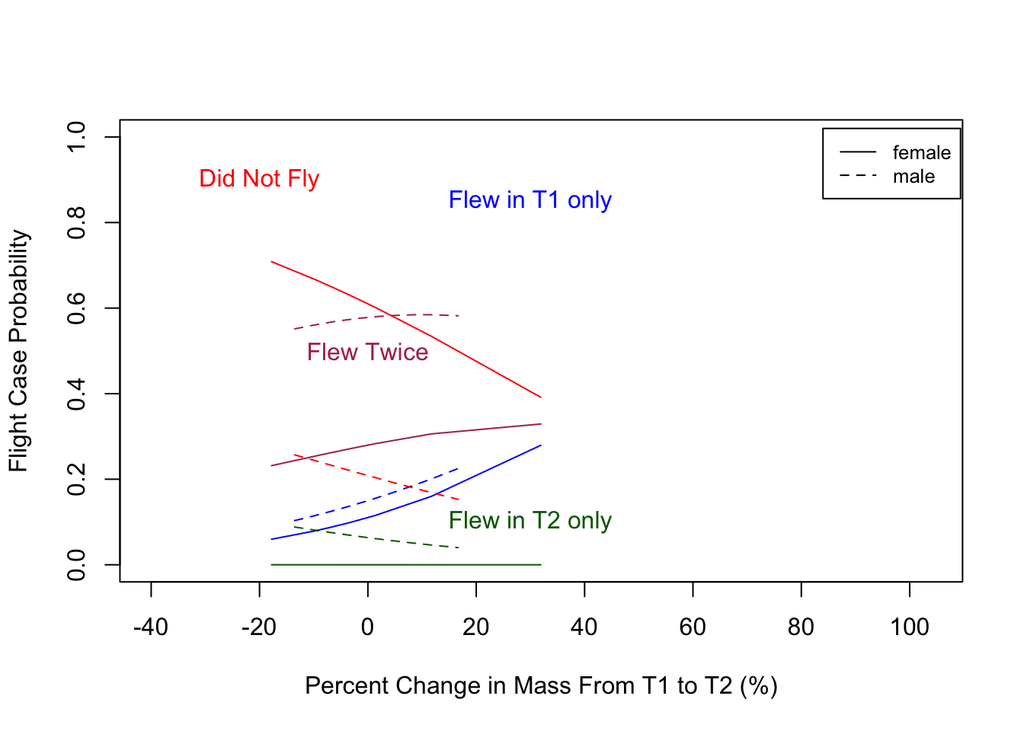

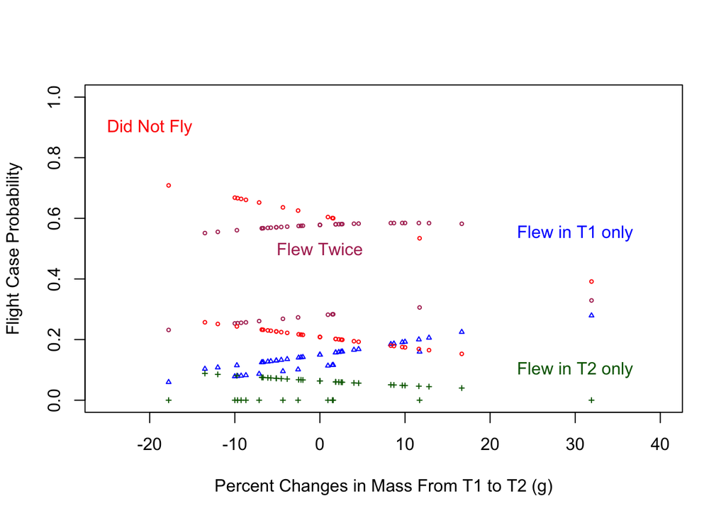

Notice that the percent change masses are much lower than the scale we had in the Winter. This suggests that there are a lot of males and few females.

**Accuracy**

```r
probs = round(cbind(neither, T1_rather_than_none, T2_rather_than_none, both_rather_than_none),2)
summary_probs = cbind(as.character(d$flight_case), as.character(d$sex), probs)
colnames(summary_probs) = c("event", "sex", "none", "T1", "T2", "both")
dataframe = as.data.frame(summary_probs)
```

```r
calculate_accuracy = function(data, cfirst, clast) {

  probs = data[cfirst:clast]
  most_likely_events = colnames(probs)[apply(probs,1,which.max)]
  actual_events = c()

  for (i in 1:nrow(data)) {
    if (data[i,1] == "0") {
      actual_event = "none"
    }
    if (data[i,1] == "-1") {
      actual_event = "T1"
    }
    if (data[i,1] == "1") {
      actual_event = "T2"
    }
    if (data[i,1] == "2") {
      actual_event = "both"
    }
    actual_events = c(actual_events, actual_event)
  }

  events = actual_events == most_likely_events
  accurate_events = sum(events)
  total_events = length(events)
  accuracy = accurate_events / total_events

  return(accuracy)
}
```

**Overall and Grouped Accuracies**

```r
# overall
acc = calculate_accuracy(dataframe,3,6)
paste("Overall prediction accuracy, ", round(acc,2))
```

```
## [1] "Overall prediction accuracy,  0.58"
```

```r
# by sex
femdata = dataframe %>%
  filter(sex=="F")
maledata = dataframe %>%
  filter(sex=="M")

accF = calculate_accuracy(femdata,3,6)
paste("Female prediction accuracy, ", round(accF,2))
```

```
## [1] "Female prediction accuracy,  0.38"
```

```r
accM = calculate_accuracy(maledata,3,6)
paste("Male prediction accuracy, ", round(accM,2))
```

```
## [1] "Male prediction accuracy,  0.66"
```

It seems like for males, this model will lead you to overestimating its flight probability. Males will not only fly twice, but they will be most likely to fly twice. Additionally, predicting female flight is much less accurate because of egg-laying events. So, let’s use the mass + eggs laid model to predict female flight case probabilities.

**Confusion Matrix**

For details see: https://medium.com/analytics-vidhya/calculating-accuracy-of-an-ml-model-8ae7894802e

and

https://stats.stackexchange.com/questions/179835/how-to-build-a-confusion-matrix-for-a-multiclass-classifier

4 X 4 Matrix

```r
acc_table = get_confusion_matrix(dataframe,3,6)
acc_table
```

```
## # A tibble: 1 x 16
##   `Overall Accura… `Balanced Accur…    F1 Sensitivity Specificity
##              <dbl>            <dbl> <dbl>       <dbl>       <dbl>
## 1            0.578            0.530   NaN       0.284       0.776
## # … with 11 more variables: `Pos Pred Value` <dbl>, `Neg Pred Value` <dbl>,
## #   Kappa <dbl>, MCC <dbl>, `Detection Rate` <dbl>, `Detection
## #   Prevalence` <dbl>, Prevalence <dbl>, Predictions <list>, `Confusion
## #   Matrix` <list>, `Class Level Results` <list>, Process <list>
```

```r
confusion_matrix <- acc_table$'Confusion Matrix'[[1]]
confusion_matrix
```

```
## # A tibble: 16 x 3
##    Prediction Target     N
##    <chr>      <chr>  <int>
##  1 both       both      21
##  2 none       both       7
##  3 T1         both       0
##  4 T2         both       0
##  5 both       none       8
##  6 none       none       5
##  7 T1         none       0
##  8 T2         none       0
##  9 both       T1         3
## 10 none       T1         0
## 11 T1         T1         0
## 12 T2         T1         0
## 13 both       T2         0
## 14 none       T2         1
## 15 T1         T2         0
## 16 T2         T2         0
```

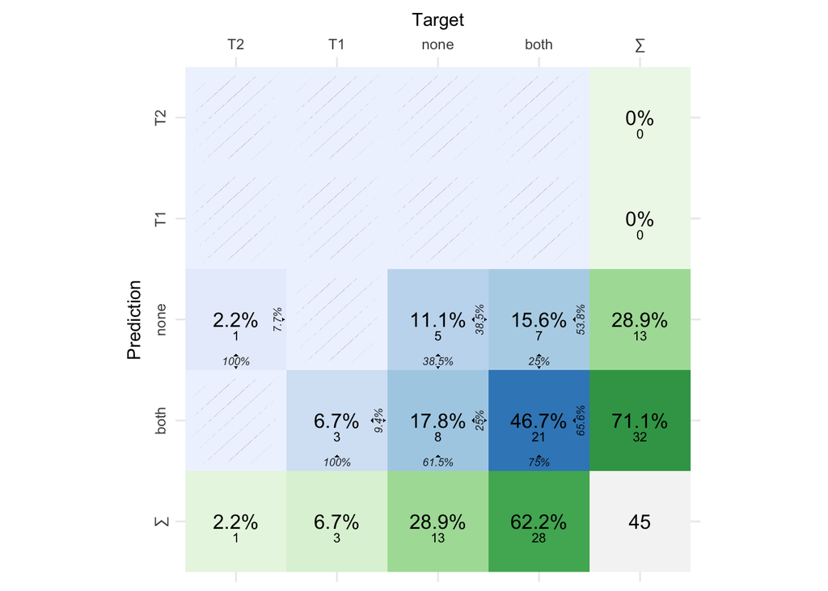

```r
plot_confusion_matrix(confusion_matrix, add_sums=TRUE)
```

For more on confusion maxtrices see: https://cran.r-project.org/web/packages/cvms/vignettes/Creating_a_confusion_matrix.html

**Females Only**

```r
d = d %>%
  filter(sex=="F")
```

- [1] “log(pi_-1 / pi_1) = -1.41 + 0.56 Egg Case + 38.73 Mass Change Flew in T1, rather than T2 trials”
- [2] “log(pi_-1 / pi_0) = -0.88 + -0.53 Egg Case + 57.43 Mass Change Flew in T1, rather than none”
- [3] “log(pi_2 / pi_0) = -0.53 + -1.09 Egg Case + 18.67 Mass Change Flew in T1, rather than none”

```r
d <- d[with(d, order(mass_diff)),]
```

```r
neither = c()
T1_rather_than_none = c()
both_rather_than_none = c()
for (i in 1:nrow(d)) {
  md = d$mass_diff[[i]]
  ed = d$egg_diff[[i]]
  top0 = exp(0) # just equals 1
  top1 = exp(-0.88 - 0.53*ed + 57.43*md )
  top2 = exp(-0.53 - 1.09*ed + 18.67*md)
  bottom = top0 + top1 + top2
  neither = c(neither, top0/bottom)
  T1_rather_than_none = c(T1_rather_than_none, top1/bottom)
  both_rather_than_none = c(both_rather_than_none, top2/bottom)
}
```

**Accuracy**

```r
probs = round(cbind(neither, T1_rather_than_none, both_rather_than_none),2)
summary_probs = cbind(as.character(d$flight_case), as.character(d$egg_diff), probs)
colnames(summary_probs) = c("event", "egg_diff", "none", "T1", "both")

egg2 = c(1,2,3,5,6,7,9,10,11,13)
noegg = c(4,8,12)

dataframe = as.data.frame(summary_probs)
dataframe$egg_cat = c(2,2,2,0,2,2,2,0,2,2,2,0,2)
```

**Plotting predicted probabilities**

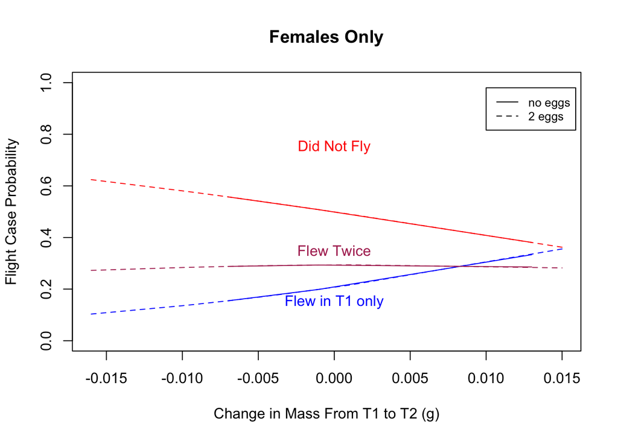

**Calculate Accuracy**

```r
accF_eggs = calculate_accuracy(dataframe,3,5)
paste("Female prediction accuracy for mass diff and egg model, ", round(accF_eggs,2))
```

```
## [1] "Female prediction accuracy for mass diff and egg model,  0.38"
```

Female flight was underestimated, and, considering that the prediction for females is so low, this leads me to believe that *season* is an important factor in predicting flight case probability.

**Confusion Matrix**

```r
acc_table = get_confusion_matrix(dataframe,3,5)
acc_table
```

```
## # A tibble: 1 x 16
##   `Overall Accura… `Balanced Accur…    F1 Sensitivity Specificity
##              <dbl>            <dbl> <dbl>       <dbl>       <dbl>
## 1            0.385              0.5   NaN       0.333       0.667
## # … with 11 more variables: `Pos Pred Value` <dbl>, `Neg Pred Value` <dbl>,
## #   Kappa <dbl>, MCC <dbl>, `Detection Rate` <dbl>, `Detection
## #   Prevalence` <dbl>, Prevalence <dbl>, Predictions <list>, `Confusion
## #   Matrix` <list>, `Class Level Results` <list>, Process <list>
```

```r
confusion_matrix <- acc_table$'Confusion Matrix'[[1]]
confusion_matrix
```

```
## # A tibble: 9 x 3
##   Prediction Target     N
##   <chr>      <chr>  <int>
## 1 both       both       0
## 2 none       both       7
## 3 T2         both       0
## 4 both       none       0
## 5 none       none       5
## 6 T2         none       0
## 7 both       T2         0
## 8 none       T2         1
## 9 T2         T2         0
```

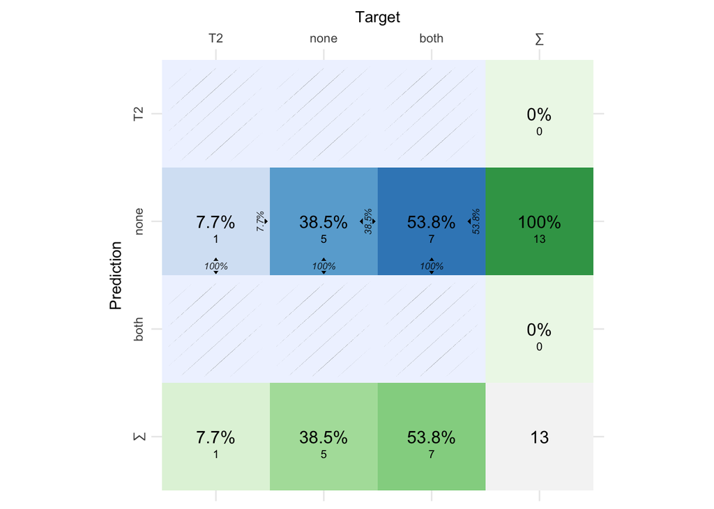

```r
plot_confusion_matrix(confusion_matrix, add_sums=TRUE)
```

**Season**

```r
source("src/clean_flight_data.R")
source("src/center_flight_data.R")
data <- read_flight_data("data/all_flight_data-Winter2020.csv")
data_all <- data[[1]]
data_tested <- data[[2]]
source("src/unique_flight_data.R")
d_all <- create_delta_data(data_tested) # winter data
winter <- center_data(d_all, is_not_binded = FALSE)

source("src/clean_flight_data-Fall.R")
d = clean_flight_data.Fall("data/all_flight_data-Fall2019.csv")
source("src/unique_flight_data-Fall.R")
fall = create_delta_data.Fall(d)

fall$season <- "fall"
winter$season <- "winter"
```

```r
# just extract the first two trials
fall$num_flew <- 0
fall$num_notflew <- 0

for(row in 1:length(fall$flew_b)){
    n_flew <- sum(fall$flew_b[[ row]][1:2] == 1)
    fall$num_flew[[ row]] <- n_flew

    n_notflew <- sum(fall$flew_b[[ row]][1:2] == 0)
    fall$num_notflew[[ row]] <- n_notflew

}
```

```r
sd = rbind(fall, winter) # unique
```

```r
sd$f_prob<-sd$num_flew/(sd$num_flew+sd$num_notflew)
```

```r
####season vs. flight prob
data_temp <- aggregate(f_prob~season, data=sd, FUN=mean)
data_temp$trials <-c(sum(sd$num_flew[sd$season=="fall"]+sd$num_notflew[sd$season=="fall"]), sum(sd$num_flew[sd$season=="winter"]+sd$num_notflew[sd$season=="winter"]))

#calculate binomial confidence interval
data_temp$successes <- c(sum(sd$num_flew[sd$season=="fall"]), sum(sd$num_flew[sd$season=="winter"]))
data_temp$CI<-binom.confint(data_temp$successes, data_temp$trials, methods="exact")
```

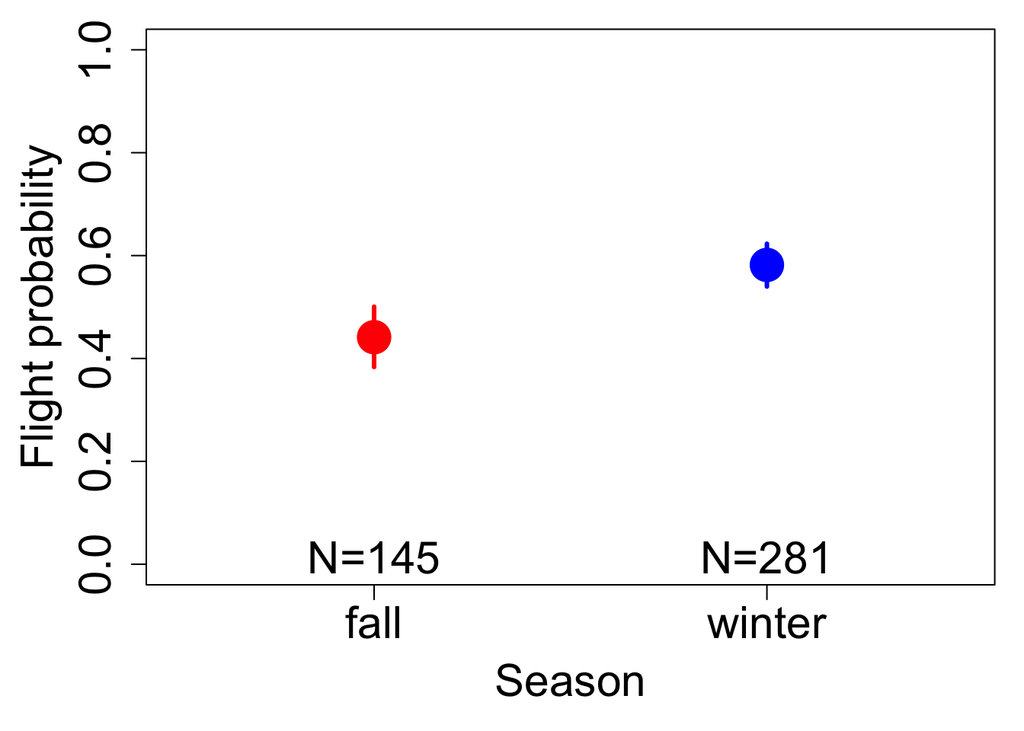

Seems like there is some difference by season for the first two trials of each bug (however, experimental setup differed).

The low accuracies could also be due to age - a factor not controlled for. Possibly younger reproductively active females fly more than older reproductively active females? It’s unclear.